# Day 1: regression and classification

## Classification

The MNIST dataset is contains hand-written images of the digits from 0 to 9. Read about it here: http://yann.lecun.com/exdb/mnist/ The original dataset of digits contains 60,000 training examples and 10,000 testing examples.

We will focus on binary classification to see if we can build a classifier to distinguish between twos and fives. But first, we will try linear regression and see why it is not a great choice for classification.

Here are a few examples of the input data:

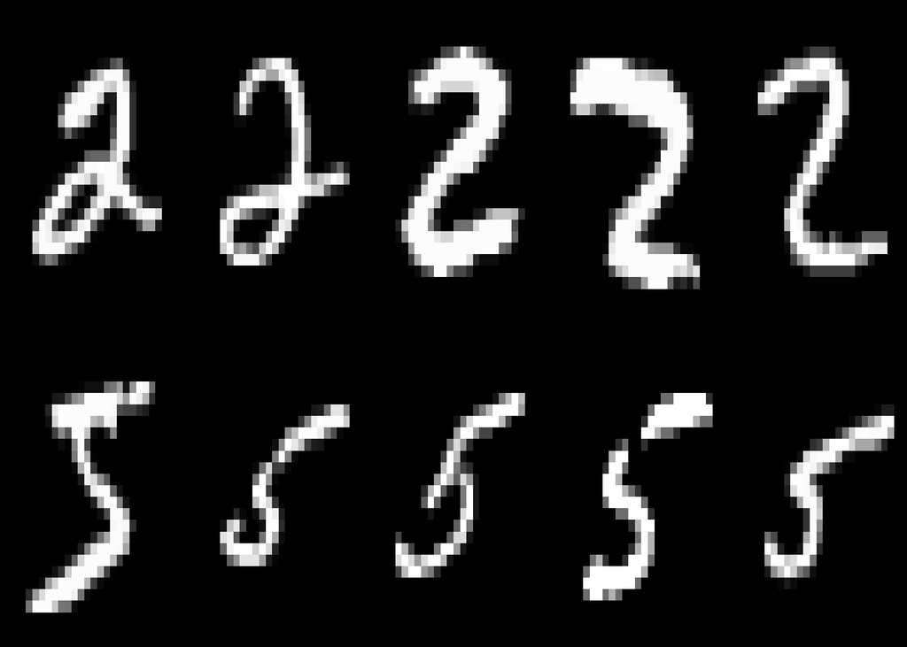

```r
load("data/mnist-2s-and-5s.RData")
marsave=par("mar")
par(mfrow=c(2,5))
par(mar=c(0, 0, 0, 0), xaxs='i', yaxs='i')

plot.digit = function(im) {
    image(1:28, 1:28, t(apply(im, 2, rev)) , col=gray((0:255)/255),
          xaxt='n',yaxt='n',xlab='n',ylab='n')
}

for(digit in c(2,5)) {
  for (idx in which(y_train == digit)[1:5]) {
    plot.digit(x_train[idx,,])
  }
}
```

**Tasks**

- Inspect the data. What format are the inputs? What format are the outputs? How big is the training dataset, `x_train` and `y_train`? How big is the test dataset, `x_test` and `y_test`?

```r
dim(x_train)
```

```
## [1] 11379    28    28
```

```r
length(y_train)
```

```
## [1] 11379
```

```r
dim(x_test)
```

```
## [1] 1924   28   28
```

```r
length(y_test)
```

```
## [1] 1924
```

```r
head(y_train)
```

```
## [1] 5 2 5 2 2 2
```

The inputs are given as arrays, indexed by observation 1, …, 11379. For each observation, there is a 28x28 matrix corresponding to the pixels. The test dataset has 1924 rows. The labels consist of integer values, i.e. `y_train` is a vector o 5’s and 2’s.

- Linear regression is not usually recommended for binary classification, but we could try it. Here is a try:

```r
X_train = as.data.frame(data.matrix(array(x_train,c(nrow(x_train),28*28)))) # reshape the inputs for linear regression
X_train$y = y_train
fit = lm(y ~ ., data=X_train)
```

- Why is linear regression a bad choice theoretically? In practice, what is wrong about our application of linear regression? Hint: look at the predictions on the training and testing data. You should make a histogram of each using `hist()`.

**Answer** Theoretically, linear regression is a method for regression, so using it for classification does not really make sense. In practice, we have labels 2 and 5—what is the interpretation of a predicted value of 3.71 or 6 or 1? More sensible if we insisted on using this method would be to use labels 0 and 1. But better would be to use an appropriate linear model for classification—the most widely used is called logistic regression.

```r
X_test = as.data.frame(data.matrix(array(x_test,c(nrow(x_test),28*28))))
X_test$y = y_test
y_train_hat = predict(fit,X_train)
y_test_hat = predict(fit,X_test)
```

- What do you think went wrong with our model when faced with the following observations? Check the coefficients of the linear model using `coef()`. (Hint: this is an example of an important concept called overfitting.)

**Answer** some of the coefficients are very very large! Think about the dataset–could it possibly be the case that a few pixel values are so much more important than the rest? The answer is no. The problem is that we have very collinear data.

```r
coefs = coef(fit)
coefs[order(-coefs)][1:10]
```

```
##        V671         V67         V64         V61 (Intercept)        V615        V198        V226        V338        V282
## 168.5278203  25.4740809  11.9045859   7.8160920   3.7981446   1.3140223   0.5707004   0.2062598   0.1395342   0.1288428
```

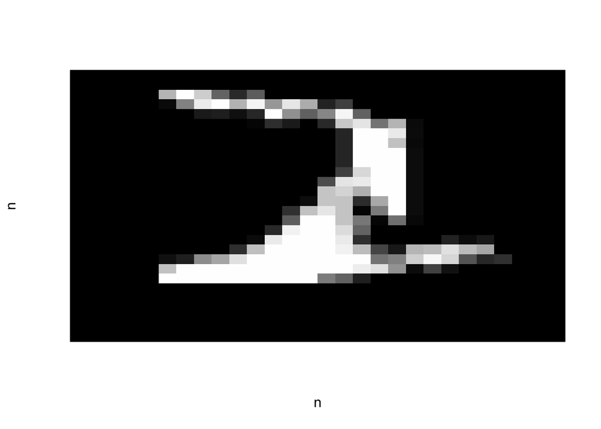

```r
plot.digit(x_test[which.min(y_test_hat),,])
```

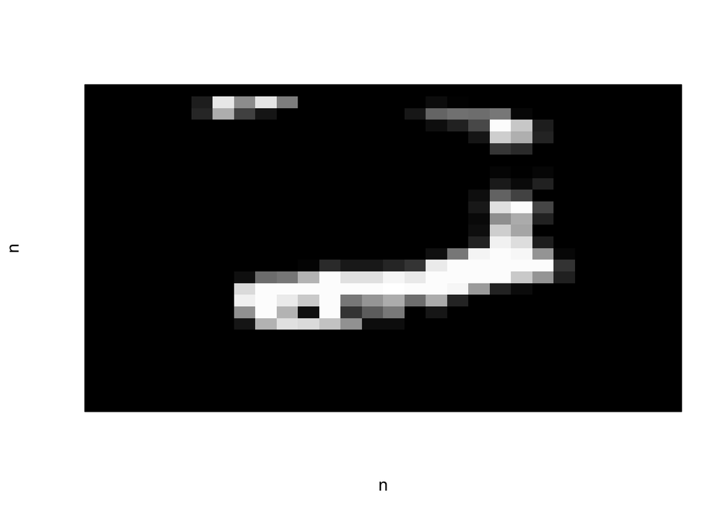

```r
plot.digit(x_test[which.max(y_test_hat),,])
```

**Build a k-nearest neighbours classifier**

- Now we are ready to try an actual classification method! Implement, from scratch, a k-nearest neighbours method. Your implementation should be in the form of a function or set of functions. It should take an input dataset `X`, set of labels `y`, value `k` (the number of nearest neighbours), and a new input `xstar` and it should return a probabilistic classification between 0 and 1 giving the probability that `xstar` is a 5. Write your function without a for loop! To test it, you should start with a small random sample of the inputs, e.g.:

```r
X_train = data.matrix(array(x_train,c(nrow(x_train),28*28)))
ii = sample(nrow(X_train),200)
X_train1 = X_train[ii,]
y_train1 = y_train[ii]
```

## Answer

```r
X_train = data.matrix(array(x_train,c(nrow(x_train),28*28)))
X_test = data.matrix(array(x_test,c(nrow(x_test),28*28)))
knn = function(X,y,k,xstar) {
  ii = order(apply(X,1,function(x) sum((x - xstar)^2)))[1:k]
  return(mean(y[ii] == 5))
}
k = 3
jj = sample(nrow(X_train),300) # subsample of training data (this is another way to speed things up)
ii = sample(nrow(X_test),200) # subsample of testing data
y_hat_test = vapply(ii,function(i) knn(X_train[jj,], y_train[jj],k,X_test[i,]),0)
mean((y_hat_test > .5) == (y_test[ii] == 5))
```

```
## [1] 0.995
```

- Test your classifier on a few training instances. Test your classifier on a few testing instances. Test your classifier on the instances that the linear regression classifier had trouble with above. What do you observe? Try different values of k. What do you observe?

See above—our classifier does very well (98%-99% test accuracy with only a fraction of the training data). Here we test it on a few values of k.

```r
jj = sample(nrow(X_train),300) # subsample of training data (this is another way to speed things up)
for(k in 2:20) {
  ii = sample(nrow(X_test),200) # subsample of testing data
  y_hat_test = vapply(ii,function(i) knn(X_train[jj,], y_train[jj],k,X_test[i,]),0)
  print(  mean((y_hat_test > .5) == (y_test[ii] == 5)))
}
```

```
## [1] 0.99
## [1] 0.985
## [1] 0.99
## [1] 0.985
## [1] 1
## [1] 0.985
## [1] 0.99
## [1] 0.995
## [1] 0.985
## [1] 1
## [1] 0.99
## [1] 0.99
## [1] 0.985
## [1] 0.985
## [1] 0.985
## [1] 0.99
## [1] 0.995
## [1] 0.985
## [1] 0.985
```

Our classifier has no problem with the instances that linear regression got wrong:

```r
print(sprintf("Prob of 5: %.02f; true class = %d",
              knn(X_train,y_train,5,x_test[which.min(y_test_hat),,]),
                y_test[which.min(y_test_hat)]))
```

```
## [1] "Prob of 5: 0.00; true class = 2"
```

```r
print(sprintf("Prob of 5: %.02f; true class = %d",
              knn(X_train,y_train,5,x_test[which.max(y_test_hat),,]),
                y_test[which.max(y_test_hat)]))
```

```
## [1] "Prob of 5: 0.00; true class = 2"
```

- Think about the right way to measure accuracy. (You have probabilistic predictions and binary labels.) What loss function is appropriate for classification?

**Answer** An appropriate loss function is LogLoss, also called cross-entropy. You can read about it here: https://towardsdatascience.com/understanding-binary-cross-entropy-log-loss-a-visual-explanation-a3ac6025181a

- Bonus: can you rewrite knn efficiently to handle multiple inputs?

**Answer** (I’m not sure why R throws warnings…not that this is relatively efficient but uses a lot of memory!)

```r
library(pdist)
knn2 = function(X,y,k,xstar) {
  dd = (pdist(X,xstar))
  n = nrow(X)
  return(vapply(1:nrow(xstar),function(i) mean(y[order(dd[1:n,i])[1:k]] == 5),0))
}
knn(X_train1,y_train1,5,X_test[1,])
```

```
## [1] 0
```

```r
knn(X_train1,y_train1,5,X_test[2,])
```

```
## [1] 0.8
```

```r
knn(X_train1,y_train1,5,X_test[3,])
```

```
## [1] 1
```

```r
knn2(X_train1,y_train1,5,X_test[1:3,])
```

```
## [1] 0.0 0.8 1.0
```